# US and Canada Covid-19 research

## Intoduction

My research compares the US and Canadian health care systems handling the Covid-19 pandemic. The study identifies the country with a higher Case Fatality Rate (the proportion of people diagnosed with Covid-19 who end up dying of it) and a higher Deaths/100K population.

Libraries used in the research:

```r
library(tidyr)
library(tidyverse)
library(lubridate)
library(modelr)
```

### Data transformation

The report is based on John Hopkins University’s publicly available datasets of Covid-19 daily cases and daily deaths (https://github.com/CSSEGISandData/COVID-19).

In addition, the report uses US and Canadian census data published officially by government authorities.

https://www150.statcan.gc.ca/t1/tbl1/en/tv.action?pid=1710000901

https://www.census.gov/newsroom/press-releases/2021/2021-population-estimates.html

```r
#download Covid cases and Covid deaths datasets and remove unused columns
base_url = "https://raw.githubusercontent.com/CSSEGISandData/COVID-19/master/csse_covid_19_data/csse_covid_19_time_series/"
covid_cases_dataset_raw <- read_csv(str_c(base_url, "time_series_covid19_confirmed_global.csv"))

covid_cases_dataset <- covid_cases_dataset_raw %>% select(-c(Lat,Long)) %>% rename(State = 'Province/State') %>% rename(Country = 'Country/Region')
covid_cases_dataset <- covid_cases_dataset %>% pivot_longer(cols= -c(State, Country), names_to = "date", values_to="total_cases")

covid_deaths_dataset_raw <- read_csv(str_c(base_url, "time_series_covid19_deaths_global.csv"))
covid_deaths_dataset <- covid_deaths_dataset_raw %>% select(-c(Lat,Long)) %>% rename(State = 'Province/State') %>% rename(Country = 'Country/Region')
covid_deaths_dataset <- covid_deaths_dataset %>% pivot_longer(cols= -c(State, Country), names_to = "date", values_to="total_deaths")

#join Covid cases with Covid deaths
covid_joined_dataset <- covid_cases_dataset %>% full_join(covid_deaths_dataset, by=c("State","Country","date"))

#filter Canada, US only rows, filter out dates when pandemic has just started and the number were still low and add new columns
covid_joined_dataset <- covid_joined_dataset %>%
  filter(Country == 'Canada' | Country == 'US') %>%
  mutate(date=mdy(date)) %>%
  filter(date > '2020-03-01') %>%
  mutate(canada_cases = case_when(Country == 'Canada' ~ total_cases, TRUE ~ 0)) %>%
  mutate(canada_deaths = case_when(Country == 'Canada' ~ total_deaths, TRUE ~ 0)) %>%
  mutate(us_cases = case_when(Country == 'US' ~ total_cases, TRUE ~ 0)) %>%
  mutate(us_deaths = case_when(Country == 'US' ~ total_deaths, TRUE ~ 0))


#group by date and sum
covid_dataset <- covid_joined_dataset  %>%
  group_by(date) %>%
  summarise(us_cases = sum(us_cases), us_deaths = sum(us_deaths), canada_cases = sum(canada_cases), canada_deaths=sum(canada_deaths))


#add new columns new_cases and new_deaths for Canada and US
#round the date to the nearest week to remove some noise
covid_dataset <- covid_dataset %>% arrange(date) %>%
  mutate(new_us_cases=us_cases-lag(us_cases)) %>%
  mutate(new_us_deaths=us_deaths-lag(us_deaths)) %>%
  mutate(new_canada_cases=canada_cases-lag(canada_cases)) %>%
  mutate(new_canada_deaths=canada_deaths-lag(canada_deaths)) %>%
  mutate(date = floor_date(date, "week"))


covid_dataset <- covid_dataset  %>%
  group_by(date) %>%
  summarise(new_us_cases = sum(new_us_cases), new_us_deaths = sum(new_us_deaths), new_canada_cases = sum(new_canada_cases), new_canada_deaths=sum(new_canada_deaths))
```

### Visualization and Analysis

The following chart of the Case Fatality Rate shows the ratio between new cases and new deaths for US and Canada.

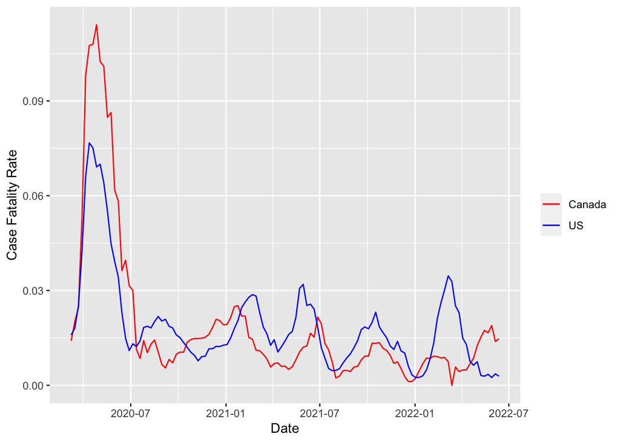

```r
#correction of wrong rows - replacing negative Canadian cases with 0, happening probably because of data collection errors
covid_dataset <- covid_dataset %>%
  mutate(new_canada_cases = replace(new_canada_cases, which(new_canada_cases<0), 0)) %>%
  mutate(new_canada_deaths = replace(new_canada_deaths, which(new_canada_deaths<0), 0)) %>%
  filter(new_canada_cases >= 0)

covid_dataset %>% ggplot(aes(x=date)) + geom_line(aes(y=new_canada_deaths/new_canada_cases, colour = 'Canada')) + geom_line(aes(, y=new_us_deaths/new_us_cases, colour = 'US')) +
  scale_colour_manual("",
                      breaks = c("Canada", "US"),
                      values = c("Canada"="red", "US"="blue")) +
  xlab('Date') +
  ylab('Case Fatality Rate')
```

#### Deaths/100K population

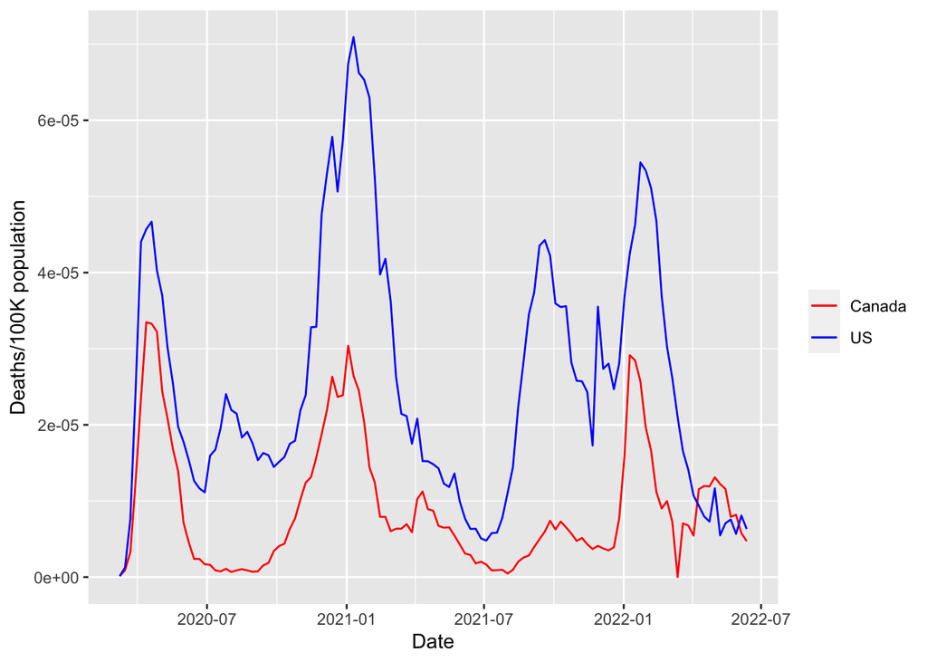

```r
canada_population = 38526760 #https://www150.statcan.gc.ca/t1/tbl1/en/tv.action?pid=1710000901
us_population = 331893745 #https://www.census.gov/newsroom/press-releases/2021/2021-population-estimates.html

covid_dataset %>% ggplot(aes(x=date)) + geom_line(aes(y=new_canada_deaths/canada_population, colour = 'Canada')) + geom_line(aes(, y=new_us_deaths/us_population, colour = 'US')) +
  scale_colour_manual("",
                      breaks = c("Canada", "US"),
                      values = c("Canada"="red", "US"="blue")) +
  xlab('Date') +
  ylab('Deaths/100K population')
```

### Modeling correlation between Canadian and US Covid cases

The following model will show a correlation between US and Canadian Covid-19 new cases.

```r
cases_linear_model <- lm(new_us_cases ~ new_canada_cases, data=covid_dataset)
summary(cases_linear_model)
```

```
##
## Call:
## lm(formula = new_us_cases ~ new_canada_cases, data = covid_dataset)
##
## Residuals:
##      Min       1Q   Median       3Q      Max
## -1510192  -161587    10551   249852  2167621
##
## Coefficients:
##                   Estimate Std. Error t value Pr(>|t|)
## (Intercept)      1.546e+05  5.722e+04   2.703   0.0079 **
## new_canada_cases 1.728e+01  1.043e+00  16.569   <2e-16 ***
## ---
## Signif. codes:  0 '***' 0.001 '**' 0.01 '*' 0.05 '.' 0.1 ' ' 1
##
## Residual standard error: 498800 on 117 degrees of freedom
## Multiple R-squared:  0.7012, Adjusted R-squared:  0.6986
## F-statistic: 274.5 on 1 and 117 DF,  p-value: < 2.2e-16
```

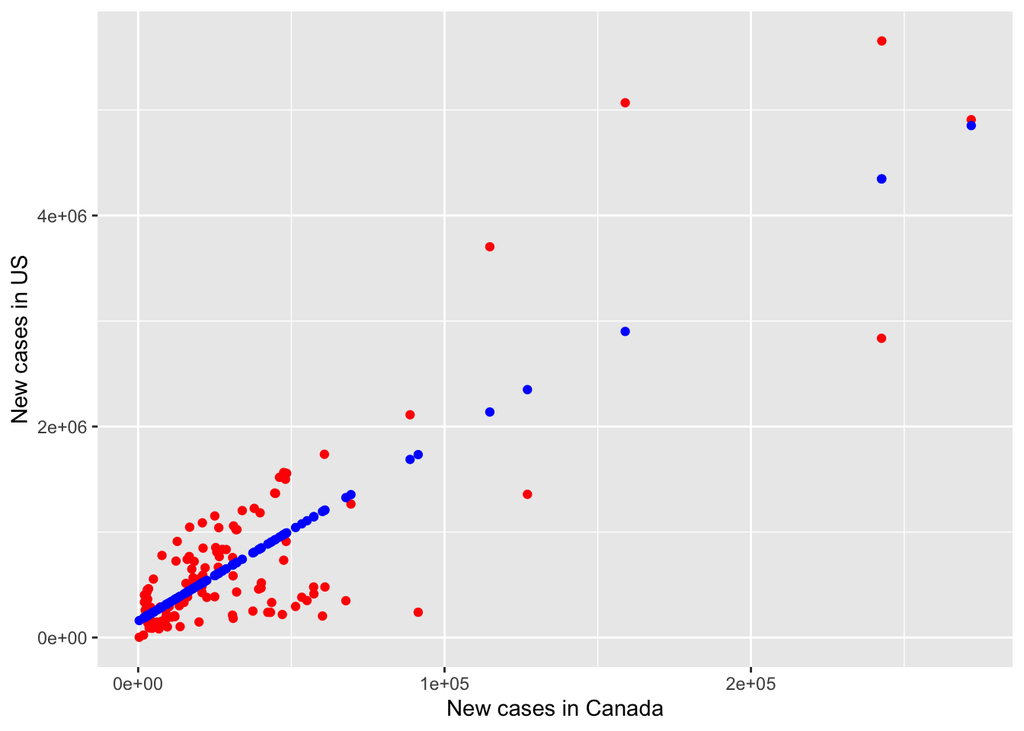

```r
cases_prediction <- cbind(covid_dataset, resid = resid(cases_linear_model), fitted = fitted(cases_linear_model))
cases_prediction %>% ggplot() + geom_point(aes(x=new_canada_cases,y=new_us_cases) , col = 'red') + geom_point(aes(x=new_canada_cases,y=fitted) , col = 'blue')  +
  xlab('New cases in Canada') +
  ylab('New cases in US')
```

Because the US and Canada share a border used heavily for travel and work from one country to another, there is a positive correlation between US and Canadian COVID-19 cases.

## Conclusion and Bias

Bias sources include bias in the John Hopkins dataset and my research. First, the number of conducted Covid-19 tests per capita in the US is almost twice as high as in Canada, leading to more virus detections. Secondly, there could be country-level biases to downward the number of deaths. Policies such as lockdowns have provoked protests against politicians, likely boosting pressure to document that the guidelines were effective. Finally, my attitude towards health care authorities may affect the results of this research.

In my opinion, despite bias sources listed above, the overall bias of this research is relatively low. Hence its results are trustworthy.